# R Capstone Project: Did Jason Sudeikis’ Actions After the European Championship Affect the Number of Google Hits About Ted Lasso?

There were mixed reactions to Britain’s loss to Italy in the European Championship this past July, but the most notable were the racist attacks against three of Britain’s players. In response, American actor Jason Sudeikis, who plays the American football coach turned British soccer coach on the AppleTV+ original Ted Lasso, wore a custom shirt that showed his solidarity with the three players to the Ted Lasso season 2 premier. In this project, I want to explore whether Sudeikis’ choice of clothing boosted the google hits for his show in both the United States and Britain.

For this project, we will need the `gtrendsR` package, installed and added to the package library below:

```r
install.packages("drat")
drat:::add("ghrr")
install.packages("gtrendsR")
 library(gtrendsR)

data("countries")
```

The first datasets I want to explore is the general interest overtime and by state/region for both keywords `Ted Lasso` and `Jason Sudeikis` in both the US and Great Britain. At first glance, it looks like the timing of Sudeikis’ commentary (July 15) was associated with a small spike in hits for `Ted Lasso` in Britain, but `Jason Sudeikis` in the US.

```r
ted_lasso_US_inq <- gtrends(keyword = "Ted Lasso",
        time = "today 1-m",
        geo = "US")

ted_lasso_GB_inq <- gtrends(keyword = "Ted Lasso",
        time = "today 1-m",
        geo = "GB")

head(ted_lasso_US_inq)
```

| date | hits | keyword | geo | time | gprop | category |
| --- | --- | --- | --- | --- | --- | --- |
| 2021-07-13 | 39 | Ted Lasso | US | today 1-m | web | 0 |
| 2021-07-14 | 36 | Ted Lasso | US | today 1-m | web | 0 |
| 2021-07-15 | 30 | Ted Lasso | US | today 1-m | web | 0 |
| 2021-07-16 | 37 | Ted Lasso | US | today 1-m | web | 0 |
| 2021-07-17 | 39 | Ted Lasso | US | today 1-m | web | 0 |
| 2021-07-18 | 38 | Ted Lasso | US | today 1-m | web | 0 |
| 2021-07-19 | 35 | Ted Lasso | US | today 1-m | web | 0 |
| 2021-07-20 | 33 | Ted Lasso | US | today 1-m | web | 0 |
| 2021-07-21 | 39 | Ted Lasso | US | today 1-m | web | 0 |
| 2021-07-22 | 59 | Ted Lasso | US | today 1-m | web | 0 |

[output cut: 20 more lines]

| location | hits | keyword | geo | gprop |
| --- | --- | --- | --- | --- |
| District of Columbia | 100 | Ted Lasso | US | web |
| Maine | 88 | Ted Lasso | US | web |
| Washington | 77 | Ted Lasso | US | web |
| Massachusetts | 72 | Ted Lasso | US | web |
| Colorado | 72 | Ted Lasso | US | web |
| Connecticut | 69 | Ted Lasso | US | web |
| Idaho | 67 | Ted Lasso | US | web |
| Rhode Island | 66 | Ted Lasso | US | web |
| Minnesota | 63 | Ted Lasso | US | web |
| Kansas | 60 | Ted Lasso | US | web |

[output cut: 41 more lines]

| location | hits | keyword | geo | gprop |
| --- | --- | --- | --- | --- |
| Charlottesville VA | 100 | Ted Lasso | US | web |
| Fairbanks AK | 96 | Ted Lasso | US | web |
| Helena MT | 94 | Ted Lasso | US | web |
| Butte-Bozeman MT | 87 | Ted Lasso | US | web |
| Grand Junction-Montrose CO | 66 | Ted Lasso | US | web |
| Twin Falls ID | 61 | Ted Lasso | US | web |
| Kansas City MO | 61 | Ted Lasso | US | web |
| Portland-Auburn ME | 60 | Ted Lasso | US | web |
| Monterey-Salinas CA | 60 | Ted Lasso | US | web |
| Bowling Green KY | 58 | Ted Lasso | US | web |

[output cut: 200 more lines]

| location | hits | keyword | geo | gprop |
| --- | --- | --- | --- | --- |
| Chicago | 100 | Ted Lasso | US | web |
| Los Angeles | 96 | Ted Lasso | US | web |
| New York | 64 | Ted Lasso | US | web |

| subject | related_topics | value | geo | keyword | category |
| --- | --- | --- | --- | --- | --- |
| 100 | top | Season | US | Ted Lasso | 0 |
| 30 | top | Casting | US | Ted Lasso | 0 |
| 24 | top | Episode | US | Ted Lasso | 0 |
| 10 | top | Apple TV | US | Ted Lasso | 0 |
| 10 | top | Apple TV HD (4th Generation) | US | Ted Lasso | 0 |
| 10 | top | Hannah Waddingham | US | Ted Lasso | 0 |
| 10 | top | Jason Sudeikis | US | Ted Lasso | 0 |
| 7 | top | Emmy Awards | US | Ted Lasso | 0 |
| 7 | top | Juno Temple | US | Ted Lasso | 0 |
| 6 | top | Primetime Emmy Awards | US | Ted Lasso | 0 |

[output cut: 23 more lines]

```r
head(ted_lasso_GB_inq)
```

| date | hits | keyword | geo | time | gprop | category |
| --- | --- | --- | --- | --- | --- | --- |
| 2021-07-13 | 38 | Ted Lasso | GB | today 1-m | web | 0 |
| 2021-07-14 | 29 | Ted Lasso | GB | today 1-m | web | 0 |
| 2021-07-15 | 19 | Ted Lasso | GB | today 1-m | web | 0 |
| 2021-07-16 | 69 | Ted Lasso | GB | today 1-m | web | 0 |
| 2021-07-17 | 68 | Ted Lasso | GB | today 1-m | web | 0 |
| 2021-07-18 | 22 | Ted Lasso | GB | today 1-m | web | 0 |
| 2021-07-19 | 17 | Ted Lasso | GB | today 1-m | web | 0 |
| 2021-07-20 | 31 | Ted Lasso | GB | today 1-m | web | 0 |
| 2021-07-21 | 36 | Ted Lasso | GB | today 1-m | web | 0 |
| 2021-07-22 | 19 | Ted Lasso | GB | today 1-m | web | 0 |

[output cut: 20 more lines]

| location | hits | keyword | geo | gprop |
| --- | --- | --- | --- | --- |
| Scotland | 100 | Ted Lasso | GB | web |
| England | 70 | Ted Lasso | GB | web |
| Wales | 66 | Ted Lasso | GB | web |
| Northern Ireland | 56 | Ted Lasso | GB | web |

| location | hits | keyword | geo | gprop |
| --- | --- | --- | --- | --- |
| London | 100 | Ted Lasso | GB | web |

| subject | related_topics | value | geo | keyword | category |
| --- | --- | --- | --- | --- | --- |
| 100 | top | Season | GB | Ted Lasso | 0 |
| 43 | top | Episode | GB | Ted Lasso | 0 |
| 43 | top | Casting | GB | Ted Lasso | 0 |
| 28 | top | Apple TV HD (4th Generation) | GB | Ted Lasso | 0 |
| 24 | top | Apple TV | GB | Ted Lasso | 0 |
| 24 | top | Hannah Waddingham | GB | Ted Lasso | 0 |
| 14 | top | Jason Sudeikis | GB | Ted Lasso | 0 |
| 14 | top | Juno Temple | GB | Ted Lasso | 0 |
| 9 | top | Brett Goldstein | GB | Ted Lasso | 0 |
| 5 | top | Review | GB | Ted Lasso | 0 |

[output cut: 5 more lines]

```
NA
```

```r
jason_US_inq <- gtrends(keyword = "Jason Sudeikis",
        time = "today 1-m",
        geo = "US",
        gprop = "news")

jason_GB_inq <- gtrends(keyword = "Jason Sudeikis",
        time = "today 1-m",
        geo = "GB",
        gprop = "news")

head(jason_US_inq)
```

| date | hits | keyword | geo | time | gprop | category |
| --- | --- | --- | --- | --- | --- | --- |
| 2021-07-13 | 0 | Jason Sudeikis | US | today 1-m | news | 0 |
| 2021-07-14 | 0 | Jason Sudeikis | US | today 1-m | news | 0 |
| 2021-07-15 | 84 | Jason Sudeikis | US | today 1-m | news | 0 |
| 2021-07-16 | 0 | Jason Sudeikis | US | today 1-m | news | 0 |
| 2021-07-17 | 0 | Jason Sudeikis | US | today 1-m | news | 0 |
| 2021-07-18 | 0 | Jason Sudeikis | US | today 1-m | news | 0 |
| 2021-07-19 | 0 | Jason Sudeikis | US | today 1-m | news | 0 |
| 2021-07-20 | 0 | Jason Sudeikis | US | today 1-m | news | 0 |
| 2021-07-21 | 0 | Jason Sudeikis | US | today 1-m | news | 0 |
| 2021-07-22 | 0 | Jason Sudeikis | US | today 1-m | news | 0 |

[output cut: 20 more lines]

| location | hits | keyword | geo | gprop |
| --- | --- | --- | --- | --- |
| Oklahoma | 100 | Jason Sudeikis | US | news |
| Florida | 12 | Jason Sudeikis | US | news |
| Texas | 10 | Jason Sudeikis | US | news |
| Alaska | NA | Jason Sudeikis | US | news |
| Alabama | NA | Jason Sudeikis | US | news |
| Arkansas | NA | Jason Sudeikis | US | news |
| Arizona | NA | Jason Sudeikis | US | news |
| California | NA | Jason Sudeikis | US | news |
| Colorado | NA | Jason Sudeikis | US | news |
| Connecticut | NA | Jason Sudeikis | US | news |

[output cut: 41 more lines]

| location | hits | keyword | geo | gprop |
| --- | --- | --- | --- | --- |
| Anchorage AK | 100 | Jason Sudeikis | US | news |
| Tyler-Longview(Lufkin & Nacogdoches) TX | 80 | Jason Sudeikis | US | news |
| Minneapolis-St. Paul MN | 7 | Jason Sudeikis | US | news |
| Houston TX | 5 | Jason Sudeikis | US | news |
| Atlanta GA | 4 | Jason Sudeikis | US | news |
| Portland-Auburn ME | NA | Jason Sudeikis | US | news |
| New York NY | NA | Jason Sudeikis | US | news |
| Binghamton NY | NA | Jason Sudeikis | US | news |
| Macon GA | NA | Jason Sudeikis | US | news |
| Philadelphia PA | NA | Jason Sudeikis | US | news |

[output cut: 200 more lines]

```r
head(jason_GB_inq)
```

| date | hits | keyword | geo | time | gprop | category |
| --- | --- | --- | --- | --- | --- | --- |
| 2021-07-13 | 0 | Jason Sudeikis | GB | today 1-m | news | 0 |
| 2021-07-14 | 0 | Jason Sudeikis | GB | today 1-m | news | 0 |
| 2021-07-15 | 0 | Jason Sudeikis | GB | today 1-m | news | 0 |
| 2021-07-16 | 0 | Jason Sudeikis | GB | today 1-m | news | 0 |
| 2021-07-17 | 0 | Jason Sudeikis | GB | today 1-m | news | 0 |
| 2021-07-18 | 0 | Jason Sudeikis | GB | today 1-m | news | 0 |
| 2021-07-19 | 0 | Jason Sudeikis | GB | today 1-m | news | 0 |
| 2021-07-20 | 0 | Jason Sudeikis | GB | today 1-m | news | 0 |
| 2021-07-21 | 0 | Jason Sudeikis | GB | today 1-m | news | 0 |
| 2021-07-22 | 0 | Jason Sudeikis | GB | today 1-m | news | 0 |

[output cut: 20 more lines]

| location | hits | keyword | geo | gprop |
| --- | --- | --- | --- | --- |
| England | NA | Jason Sudeikis | GB | news |
| Northern Ireland | NA | Jason Sudeikis | GB | news |
| Scotland | NA | Jason Sudeikis | GB | news |
| Wales | NA | Jason Sudeikis | GB | news |

Next, I will put together a dataframe of the general interest over time in both topics for both the US and Britain.

```r
interest_df <- bind_rows(jason_GB_inq$interest_over_time,
                         jason_US_inq$interest_over_time,
                         ted_lasso_GB_inq$interest_over_time,
                         ted_lasso_US_inq$interest_over_time)
```

To visualize the trends for both keywords in both the US and Britain, I created a faceted line graph using ggplot2.

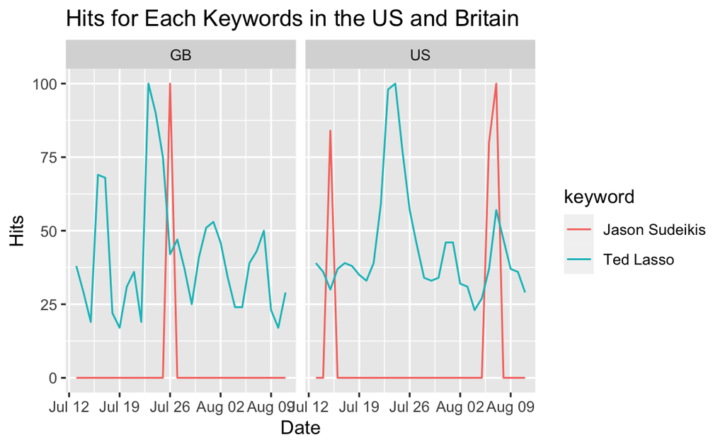

```r
interest_viz <- interest_df %>%
                ggplot(aes(x = date, y = hits)) +
                facet_grid(cols = vars(geo)) +
                geom_line(aes(color = keyword)) +
                labs(title = "Hits for Each Keywords in the US and Britain", y = "Hits", x = "Date")




interest_viz
```

Sudeikis’ commentary instead produced a spike in hits for his own name on July 15 and the show on July 23. The spike for his name on August 5-7 could be attributed to other causes, such as interviews done in the US or his appearance on the cover of GQ magazine.

Though we can probably extrapolate the effects of each search term on the other through these visuals alone, I created a linear regression model for each country. In order to do that, I will have to break apart `interest_df` and recombine it to get the dataframes that will work with a linear regression.

Our null hypothesis: There is no effect on the hits for Ted Lasso when hits for Jason Sudeikis increase.

```r
interest_GB_sudeikis <- interest_df %>%
              filter(geo == "GB", keyword == "Jason Sudeikis") %>%
              rename(keyword_sudeikis = keyword, hits_sudeikis = hits)

interest_GB_lasso <- interest_df %>%
              filter(geo == "GB", keyword == "Ted Lasso") %>%
              rename(keyword_lasso = keyword, hits_lasso = hits)

interest_GB <- bind_cols(interest_GB_lasso$keyword_lasso,
                         interest_GB_sudeikis$keyword_sudeikis,
                         interest_GB_lasso$hits_lasso,
                         interest_GB_sudeikis$hits_sudeikis)
```

```
* NA -> ...1
* NA -> ...2
* NA -> ...3
* NA -> ...4
```

```r
interest_GB <- interest_GB %>%
              rename("hits_lasso" = "...3",
                     "hits_sudeikis" = "...4")

interest_US_sudeikis <- interest_df %>%
              filter(geo == "US", keyword == "Jason Sudeikis") %>%
              rename(keyword_sudeikis = keyword, hits_sudeikis = hits)

interest_US_lasso <- interest_df %>%
              filter(geo == "US", keyword == "Ted Lasso") %>%
              rename(keyword_lasso = keyword, hits_lasso = hits)

interest_US <- bind_cols(interest_US_lasso$keyword_lasso,
                         interest_US_sudeikis$keyword_sudeikis,
                         interest_US_lasso$hits_lasso,
                         interest_US_sudeikis$hits_sudeikis)
```

```
* NA -> ...1
* NA -> ...2
* NA -> ...3
* NA -> ...4
```

```r
interest_US <- interest_US %>%
              rename("hits_lasso" = "...3",
                     "hits_sudeikis" = "...4")
```

*Takes a breath* ok, done. Now, let’s create some linear models

```r
model_US <- lm(hits_lasso ~ hits_sudeikis, data = interest_US)

summary(model_US)
```

```
Call:
lm(formula = hits_lasso ~ hits_sudeikis, data = interest_US)

Residuals:
    Min      1Q  Median      3Q     Max
-20.849 -10.599  -6.349   2.151  56.151

Coefficients:
              Estimate Std. Error t value Pr(>|t|)
(Intercept)   43.84858    3.65068  12.011 1.46e-12 ***
hits_sudeikis -0.01688    0.13056  -0.129    0.898
---
Signif. codes:  0 ‘***’ 0.001 ‘**’ 0.01 ‘*’ 0.05 ‘.’ 0.1 ‘ ’ 1

Residual standard error: 18.98 on 28 degrees of freedom
Multiple R-squared:  0.0005969, Adjusted R-squared:  -0.0351
F-statistic: 0.01672 on 1 and 28 DF,  p-value: 0.898
```

```r
model_GB <- lm(hits_lasso ~ hits_sudeikis, data = interest_GB)

summary(model_GB)
```

```
Call:
lm(formula = hits_lasso ~ hits_sudeikis, data = interest_GB)

Residuals:
    Min      1Q  Median      3Q     Max
-24.241 -16.991  -3.741   8.009  58.759

Coefficients:
               Estimate Std. Error t value Pr(>|t|)
(Intercept)   41.241379   4.011884  10.280 5.22e-11 ***
hits_sudeikis  0.007586   0.219740   0.035    0.973
---
Signif. codes:  0 ‘***’ 0.001 ‘**’ 0.01 ‘*’ 0.05 ‘.’ 0.1 ‘ ’ 1

Residual standard error: 21.6 on 28 degrees of freedom
Multiple R-squared:  4.257e-05, Adjusted R-squared:  -0.03567
F-statistic: 0.001192 on 1 and 28 DF,  p-value: 0.9727
```

According to the summary, both models have p-values greater than 0.05, which for me signals that we cannot reject the null hypothesis. This in mind, let’s see what a linear regression graph would look like for both.

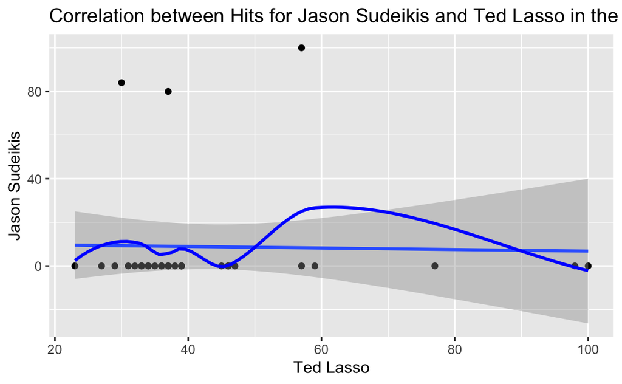

```r
model_US_viz <- interest_US %>%
                ggplot(aes(x=hits_lasso, y=hits_sudeikis)) +
                geom_point() +
                geom_smooth(method = "lm") +
                geom_smooth(se = FALSE, color = "blue") +
                labs(title = "Correlation between Hits for Jason Sudeikis and Ted Lasso in the US", x = "Ted Lasso", y = "Jason Sudeikis")

model_US_viz
```

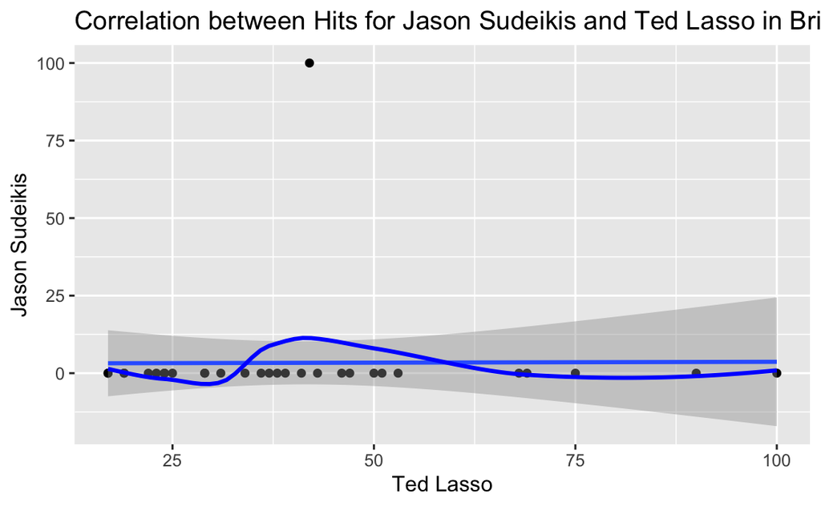

```r
model_GB_viz <- interest_GB %>%
                ggplot(aes(x=hits_lasso, y=hits_sudeikis)) +
                geom_point() +
                geom_smooth(method = "lm") +
                geom_smooth(se = FALSE, color = "blue") +
                labs(title = "Correlation between Hits for Jason Sudeikis and Ted Lasso in Britain", x = "Ted Lasso", y = "Jason Sudeikis")

model_GB_viz
```

Because most of the values of the values for the hits for Jason Sudeikis are zero and there are between one and three outliers, the linear correlation is pretty much non-existant. From these graphs, it is also difficult to tell whether there would be a linear correlation even if Jason Sudeikis got more hits per day.

In conclusion, the British were more interested in what Jason Sudeikis had to do with Britain, so they looked up his show, and people in the United States were more interest in Jason Sudeikis’ racial commentary, so they looked up what happened on July 15. Having lived in the U.S. for all of my life, this behavior among Americans seems typical. Also, when the hits for Ted Lasso increase, the hits for Jason Sudeikis do not. If one day Jason Sudeikis was more recognizable, or if Ted Lasso itself became more famous as a show, I would like to try to rerun this simulation. Perhaps then there would be a correlation.